# examples_0522

Consider the [L system](https://en.wikipedia.org/wiki/L-system) defined by the following start and replacement rules:

- Start = I
- Rules:
  - G → IGS
  - I → SGSG
  - S → GIS

After 2 iterations, what string is developed?

- I
- SGSG
- GISIGSGISIGS

GISIGSGISIGS

Consider the [L system](https://en.wikipedia.org/wiki/L-system) defined by the following start and replacement rules:

- Start = G
- Rules:
  - E → EEM
  - G → EG
  - M → MG

After 2 iterations, what string is developed?

- G
- EG
- EEMEG

EEMEG

Consider the [L system](https://en.wikipedia.org/wiki/L-system) defined by the following start and replacement rules:

- Start = KK
- Rules:
  - I → VVK
  - K → VV
  - V → IVK

After 2 iterations, what string is developed?

- KK
- VVVV
- IVKIVKIVKIVK

IVKIVKIVKIVK

Consider the [L system](https://en.wikipedia.org/wiki/L-system) defined by the following start and replacement rules:

- Start = W
- Rules:
  - O → VWVW
  - V → OV
  - W → VVVW

After 2 iterations, what string is developed?

- W
- VVVW
- OVOVOVVVVW

OVOVOVVVVW

Consider the [L system](https://en.wikipedia.org/wiki/L-system) defined by the following start and replacement rules:

- Start = L
- Rules:
  - I → LL
  - J → II
  - L → LLJ

After 2 iterations, what string is developed?

- L
- LLJ
- LLJLLJII

LLJLLJII

Consider the [L system](https://en.wikipedia.org/wiki/L-system) defined by the following start and replacement rules:

- Start = C
- Rules:
  - B → VCE
  - C → CB
  - E → CEV
  - V → CEC

After 2 iterations, what string is developed?

- C
- CB
- CBVCE

CBVCE

Consider the [L system](https://en.wikipedia.org/wiki/L-system) defined by the following start and replacement rules:

- Start = ZH
- Rules:
  - E → HV
  - H → HZ
  - V → HE
  - Z → ZV

After 2 iterations, what string is developed?

- ZH
- ZVHZ
- ZVHEHZZV

ZVHEHZZV

Consider the [L system](https://en.wikipedia.org/wiki/L-system) defined by the following start and replacement rules:

- Start = J
- Rules:
  - A → JLDA
  - D → AJ
  - J → LJJ
  - L → ADJJ

After 2 iterations, what string is developed?

- J
- LJJ
- ADJJLJJLJJ

ADJJLJJLJJ

Consider the [L system](https://en.wikipedia.org/wiki/L-system) defined by the following start and replacement rules:

- Start = D
- Rules:
  - D → PFPD
  - F → PPP
  - P → FD

After 2 iterations, what string is developed?

- D
- PFPD
- FDPPPFDPFPD

FDPPPFDPFPD

Consider the [L system](https://en.wikipedia.org/wiki/L-system) defined by the following start and replacement rules:

- Start = W
- Rules:
  - C → WHC
  - H → OHW
  - O → CC
  - W → OHHW

After 2 iterations, what string is developed?

- W
- OHHW
- CCOHWOHWOHHW

CCOHWOHWOHHW

Consider the [L system](https://en.wikipedia.org/wiki/L-system) defined by the following start and replacement rules:

- Start = NRG
- Rules:
  - G $\to$ GN
  - N $\to$ RGN
  - R $\to$ GR

After 4 iterations, what string is developed? I'd recommend using [this tool](https://chadworley.github.io/Lsys_string_gen.html).

Consider the [L system](https://en.wikipedia.org/wiki/L-system) defined by the following start and replacement rules:

- Start = JJ
- Rules:
  - G $\to$ GS
  - J $\to$ SS
  - S $\to$ GSJ

After 4 iterations, what string is developed? I'd recommend using [this tool](https://chadworley.github.io/Lsys_string_gen.html).

Consider the [L system](https://en.wikipedia.org/wiki/L-system) defined by the following start and replacement rules:

- Start = PX
- Rules:
  - K $\to$ XMPP
  - M $\to$ KXMP
  - P $\to$ MPXX
  - X $\to$ PMM

After 3 iterations, what string is developed? I'd recommend using [this tool](https://chadworley.github.io/Lsys_string_gen.html).

Consider the [L system](https://en.wikipedia.org/wiki/L-system) defined by the following start and replacement rules:

- Start = R
- Rules:
  - B $\to$ RR
  - R $\to$ TB
  - T $\to$ BBT

After 5 iterations, what string is developed? I'd recommend using [this tool](https://chadworley.github.io/Lsys_string_gen.html).

Consider the [L system](https://en.wikipedia.org/wiki/L-system) defined by the following start and replacement rules:

- Start = CC
- Rules:
  - C $\to$ KKC
  - K $\to$ LC
  - L $\to$ KK

After 4 iterations, what string is developed? I'd recommend using [this tool](https://chadworley.github.io/Lsys_string_gen.html).

Consider the [L system](https://en.wikipedia.org/wiki/L-system) defined by the following start and replacement rules:

- Start = C
- Rules:
  - C $\to$ GJG
  - G $\to$ CG
  - J $\to$ GG

After 5 iterations, what string is developed? I'd recommend using [this tool](https://chadworley.github.io/Lsys_string_gen.html).

Consider the [L system](https://en.wikipedia.org/wiki/L-system) defined by the following start and replacement rules:

- Start = HMW
- Rules:
  - H $\to$ WH
  - M $\to$ RH
  - R $\to$ MHR
  - W $\to$ RW

After 4 iterations, what string is developed? I'd recommend using [this tool](https://chadworley.github.io/Lsys_string_gen.html).

Consider the [L system](https://en.wikipedia.org/wiki/L-system) defined by the following start and replacement rules:

- Start = FB
- Rules:
  - A $\to$ AAAF
  - B $\to$ FBF
  - F $\to$ ABAF

After 3 iterations, what string is developed? I'd recommend using [this tool](https://chadworley.github.io/Lsys_string_gen.html).

Consider the [L system](https://en.wikipedia.org/wiki/L-system) defined by the following start and replacement rules:

- Start = B
- Rules:
  - B $\to$ JZZZ
  - C $\to$ CZJZ
  - J $\to$ BCJ
  - Z $\to$ ZJ

After 4 iterations, what string is developed? I'd recommend using [this tool](https://chadworley.github.io/Lsys_string_gen.html).

Consider the [L system](https://en.wikipedia.org/wiki/L-system) defined by the following start and replacement rules:

- Start = WZ
- Rules:
  - A $\to$ WA
  - W $\to$ AAW
  - Z $\to$ AZZ

After 4 iterations, what string is developed? I'd recommend using [this tool](https://chadworley.github.io/Lsys_string_gen.html).

A turtle starts at the central red dot facing North. It uses the following commands:

- Character `F` means drag pen **Forward**
- Character `+` means turn 90° right (clockwise)
- Character `-` means turn 90° left (counterclockwise)
- Character `X` means hop forward without drawing
- Character `[` means save current position at top of pile
- Character `]` means teleport to saved position (use position at top of pile and remove that position from pile)

Use the following command string:

`F[-FFFFFFFF]FFFFFF+FFFFFF+FFFFF`

Which drawing is correct?

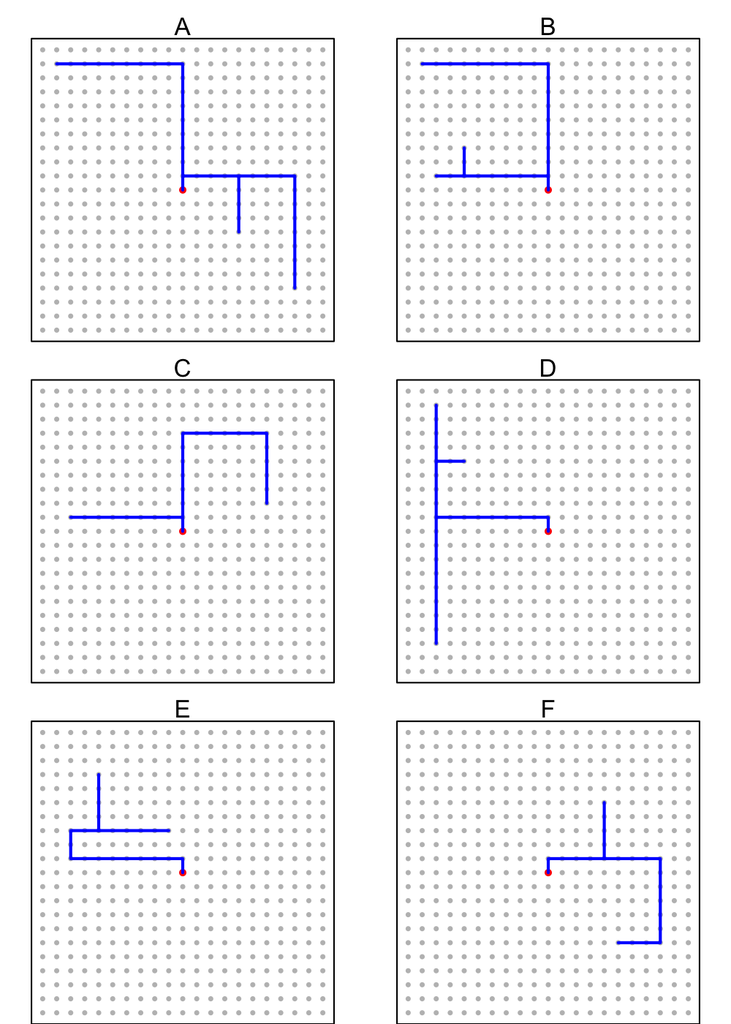

ABCDEF

The correct answer is C.

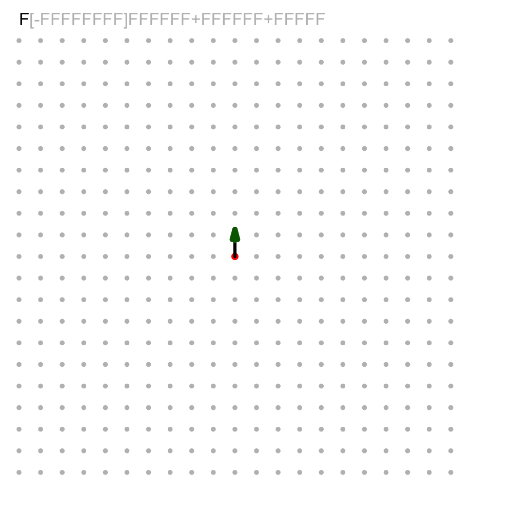

A turtle starts at the central red dot facing North. It uses the following commands:

- Character `F` means drag pen **Forward**
- Character `+` means turn 90° right (clockwise)
- Character `-` means turn 90° left (counterclockwise)
- Character `X` means hop forward without drawing
- Character `[` means save current position at top of pile
- Character `]` means teleport to saved position (use position at top of pile and remove that position from pile)

Use the following command string:

`F[-FFFFFFFF+FFFFFFFF]FF-FFFFFF-FFFFFFFFF`

Which drawing is correct?

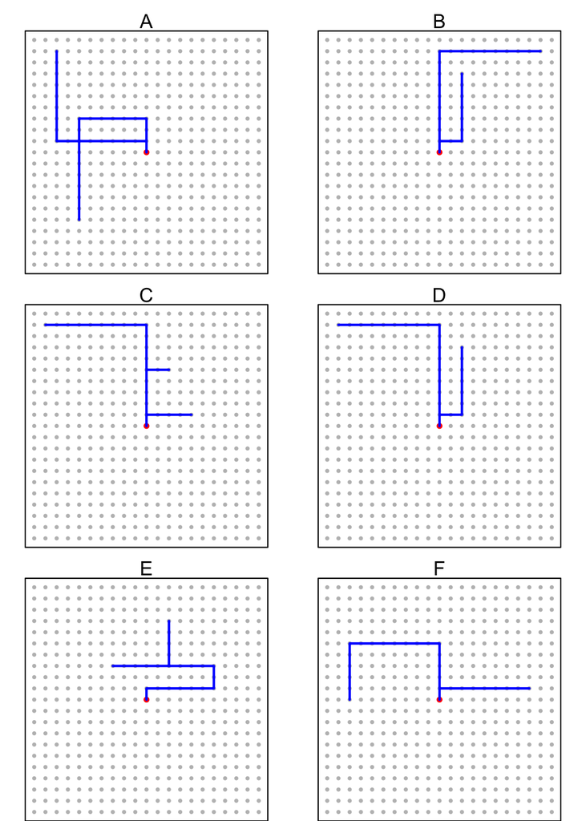

ABCDEF

The correct answer is A.

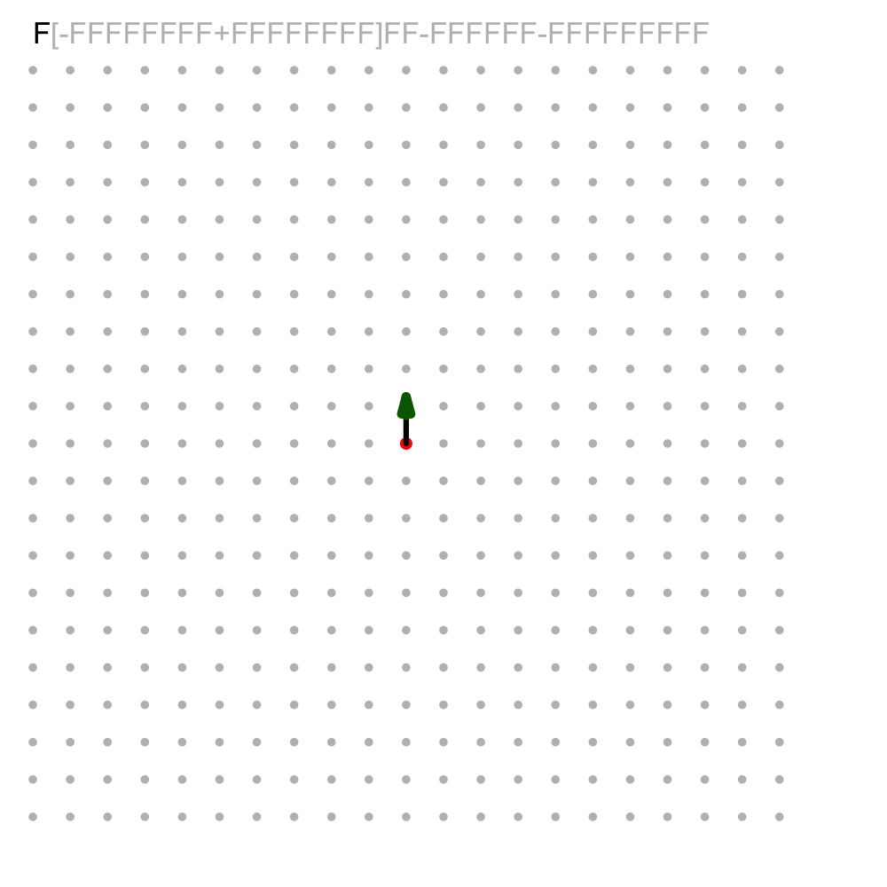

A turtle starts at the central red dot facing North. It uses the following commands:

- Character `F` means drag pen **Forward**
- Character `+` means turn 90° right (clockwise)
- Character `-` means turn 90° left (counterclockwise)
- Character `X` means hop forward without drawing
- Character `[` means save current position at top of pile
- Character `]` means teleport to saved position (use position at top of pile and remove that position from pile)

Use the following command string:

`F[-FFFFFFFF-FFFFFFFF]FFFFFF-FF-FFFFFFFFF`

Which drawing is correct?

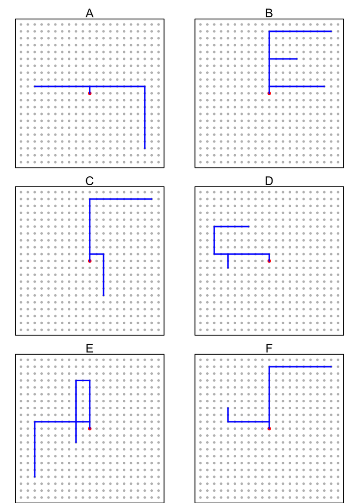

ABCDEF

The correct answer is E.

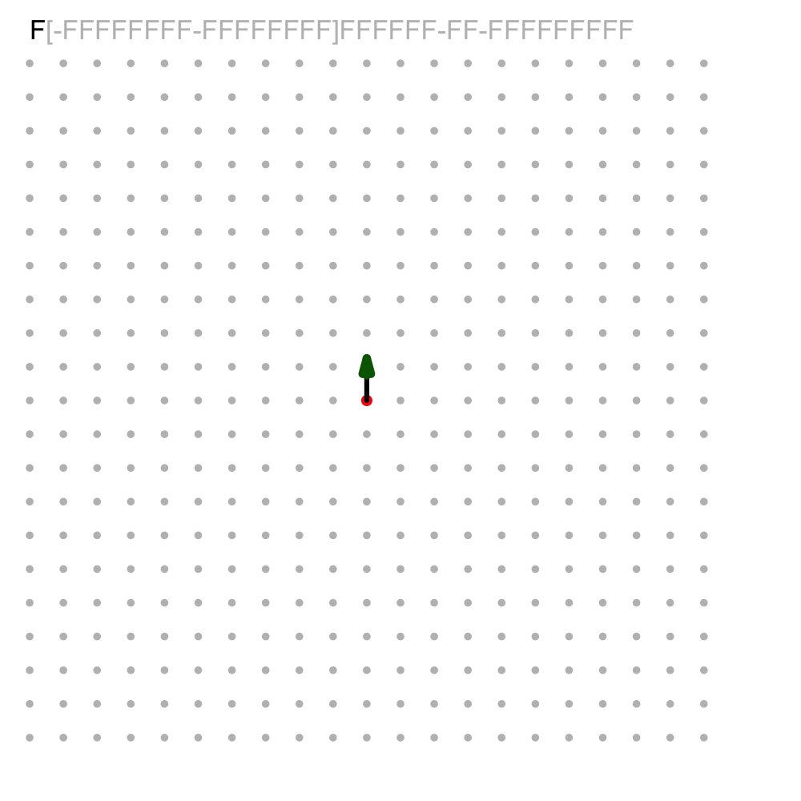

A turtle starts at the central red dot facing North. It uses the following commands:

- Character `F` means drag pen **Forward**
- Character `+` means turn 90° right (clockwise)
- Character `-` means turn 90° left (counterclockwise)
- Character `X` means hop forward without drawing
- Character `[` means save current position at top of pile
- Character `]` means teleport to saved position (use position at top of pile and remove that position from pile)

Use the following command string:

`F-FFFF-FFFF-FFFFFF[+FF]FFF`

Which drawing is correct?

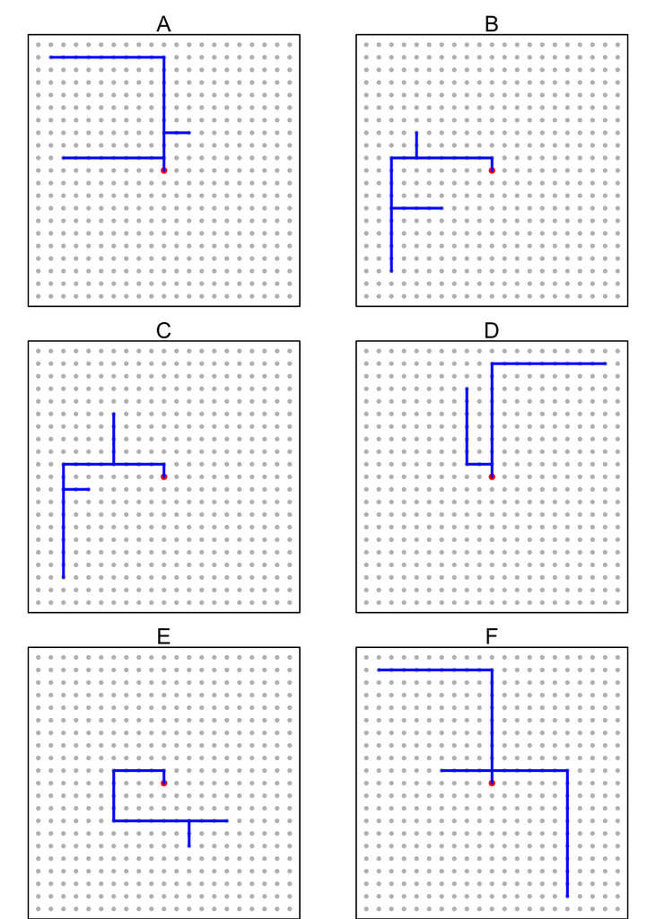

ABCDEF

The correct answer is E.

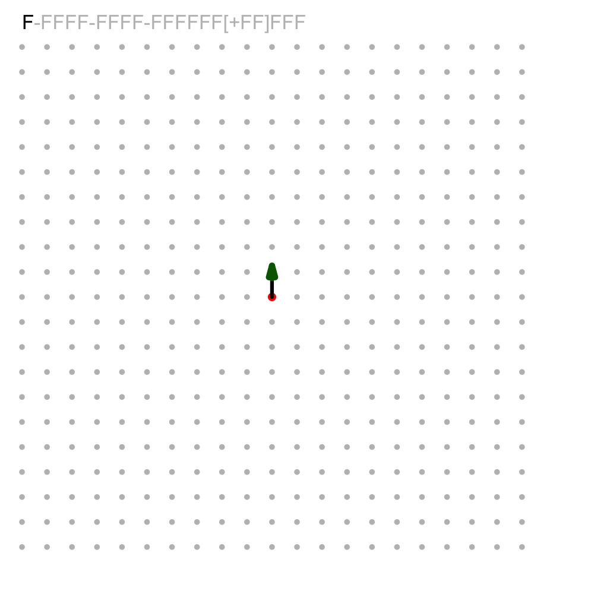

A turtle starts at the central red dot facing North. It uses the following commands:

- Character `F` means drag pen **Forward**
- Character `+` means turn 90° right (clockwise)
- Character `-` means turn 90° left (counterclockwise)
- Character `X` means hop forward without drawing
- Character `[` means save current position at top of pile
- Character `]` means teleport to saved position (use position at top of pile and remove that position from pile)

Use the following command string:

`F-FFFF[-FFFF][+FF]FFFF-FFFFFFFFF`

Which drawing is correct?

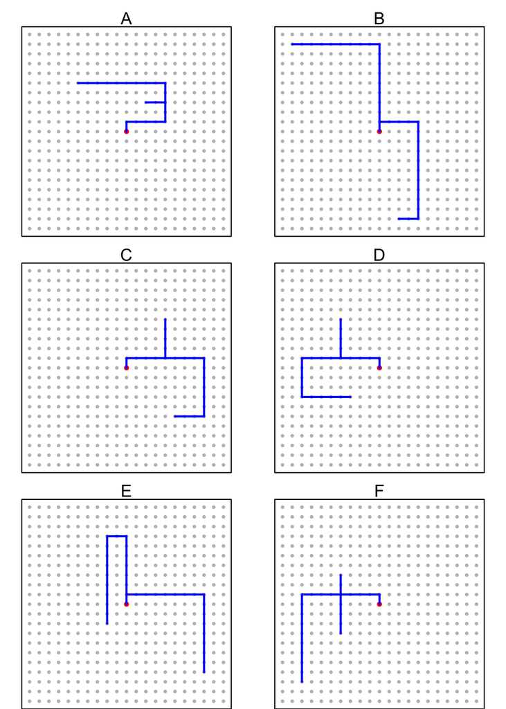

ABCDEF

The correct answer is F.

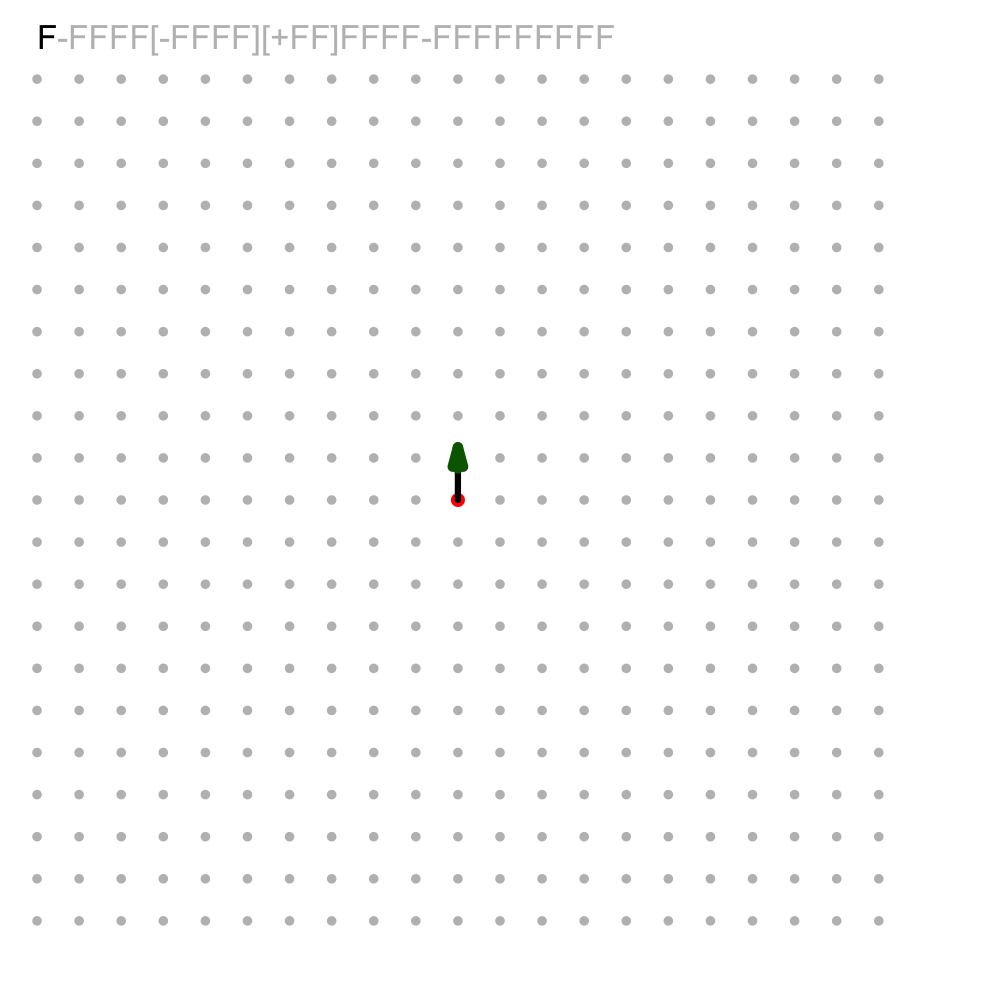

A turtle starts at the central red dot facing North. It uses the following commands:

- Character `F` means drag pen **Forward**
- Character `+` means turn 90° right (clockwise)
- Character `-` means turn 90° left (counterclockwise)
- Character `X` means hop forward without drawing
- Character `[` means save current position at top of pile
- Character `]` means teleport to saved position (use position at top of pile and remove that position from pile)

Use the following command string:

`F[-FFFFFFFF-FFFFFFFF][+FFFF]FFFFFFFF-FFFFFFFFF`

Which drawing is correct?

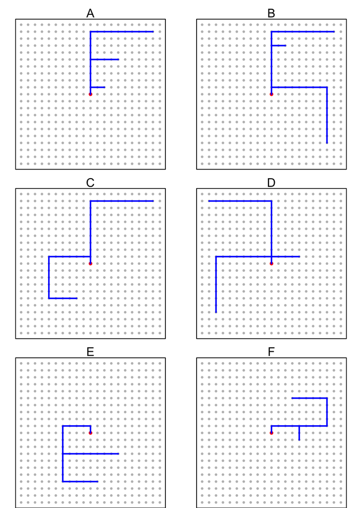

ABCDEF

The correct answer is D.

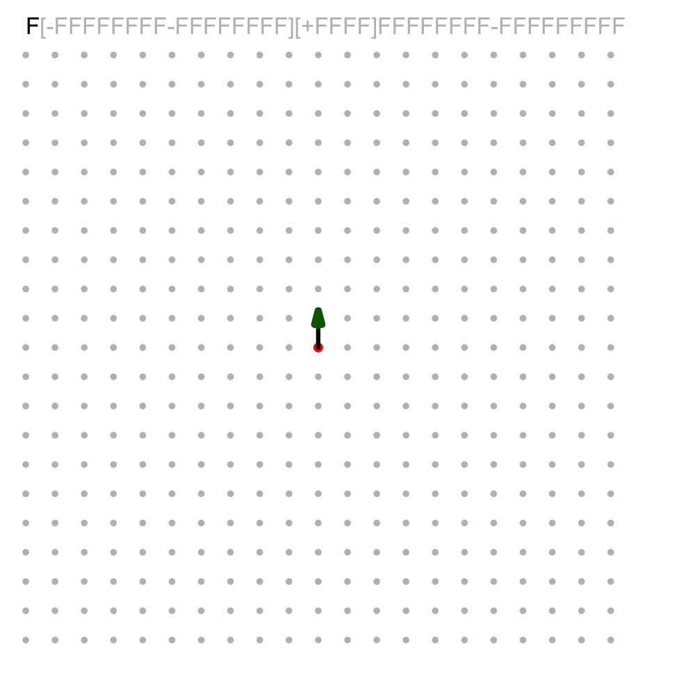

A turtle starts at the central red dot facing North. It uses the following commands:

- Character `F` means drag pen **Forward**
- Character `+` means turn 90° right (clockwise)
- Character `-` means turn 90° left (counterclockwise)
- Character `X` means hop forward without drawing
- Character `[` means save current position at top of pile
- Character `]` means teleport to saved position (use position at top of pile and remove that position from pile)

Use the following command string:

`F[+FFFF][-FF]FFFFFFFF-FFFFFFFFF`

Which drawing is correct?

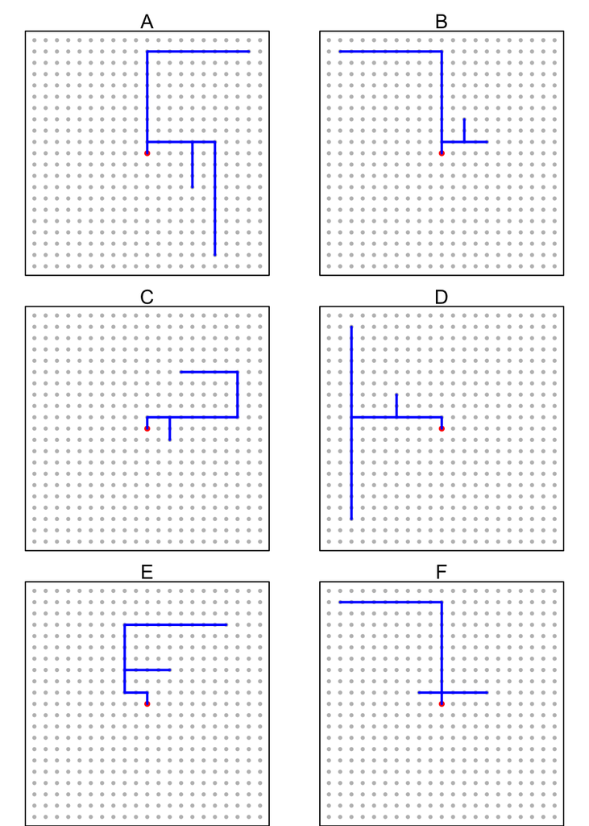

ABCDEF

The correct answer is F.

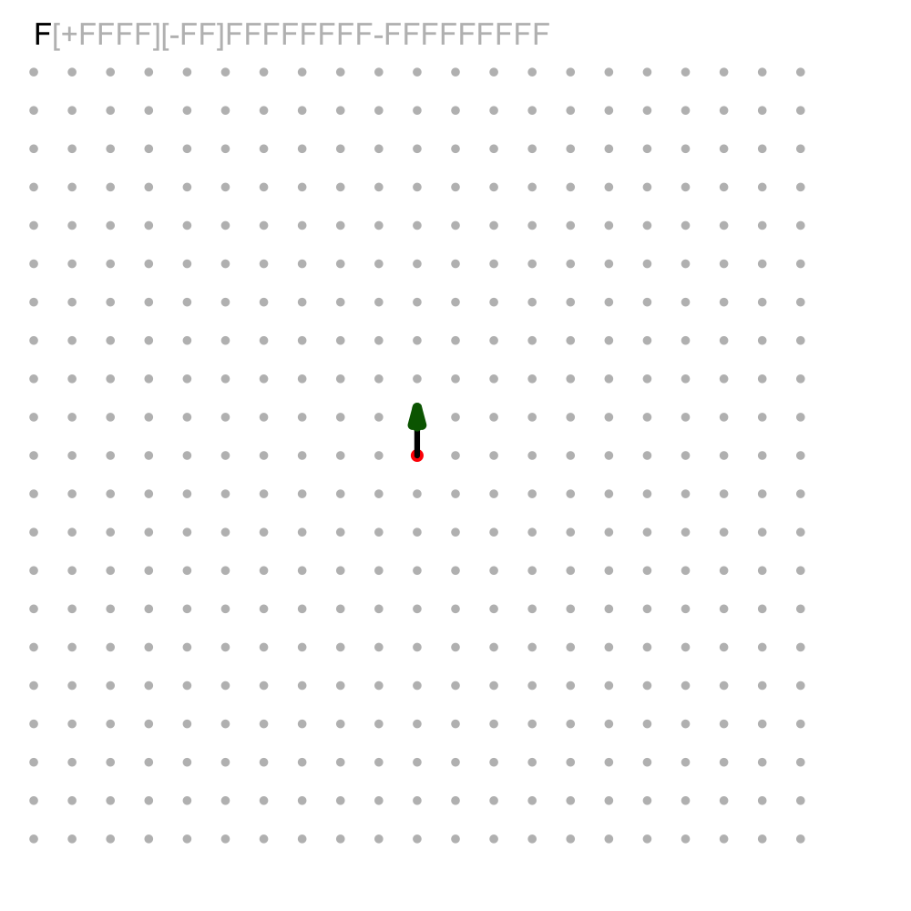

A turtle starts at the central red dot facing North. It uses the following commands:

- Character `F` means drag pen **Forward**
- Character `+` means turn 90° right (clockwise)
- Character `-` means turn 90° left (counterclockwise)
- Character `X` means hop forward without drawing
- Character `[` means save current position at top of pile
- Character `]` means teleport to saved position (use position at top of pile and remove that position from pile)

Use the following command string:

`F-FFFFFF+FF+FFFF[+FFFF]FFFFF`

Which drawing is correct?

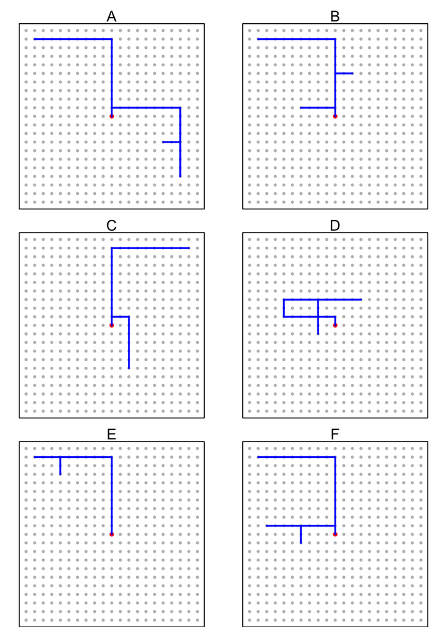

ABCDEF

The correct answer is D.

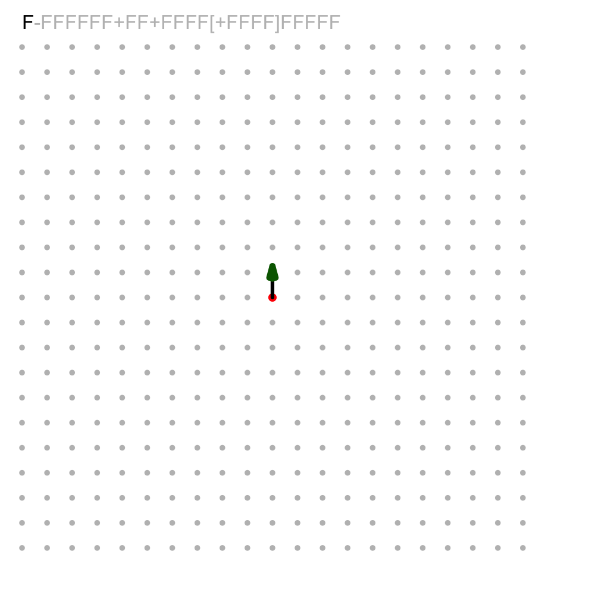

A turtle starts at the central red dot facing North. It uses the following commands:

- Character `F` means drag pen **Forward**
- Character `+` means turn 90° right (clockwise)
- Character `-` means turn 90° left (counterclockwise)
- Character `X` means hop forward without drawing
- Character `[` means save current position at top of pile
- Character `]` means teleport to saved position (use position at top of pile and remove that position from pile)

Use the following command string:

`F[-FFFF]FFFFFF+FF+FFFFFFFFF`

Which drawing is correct?

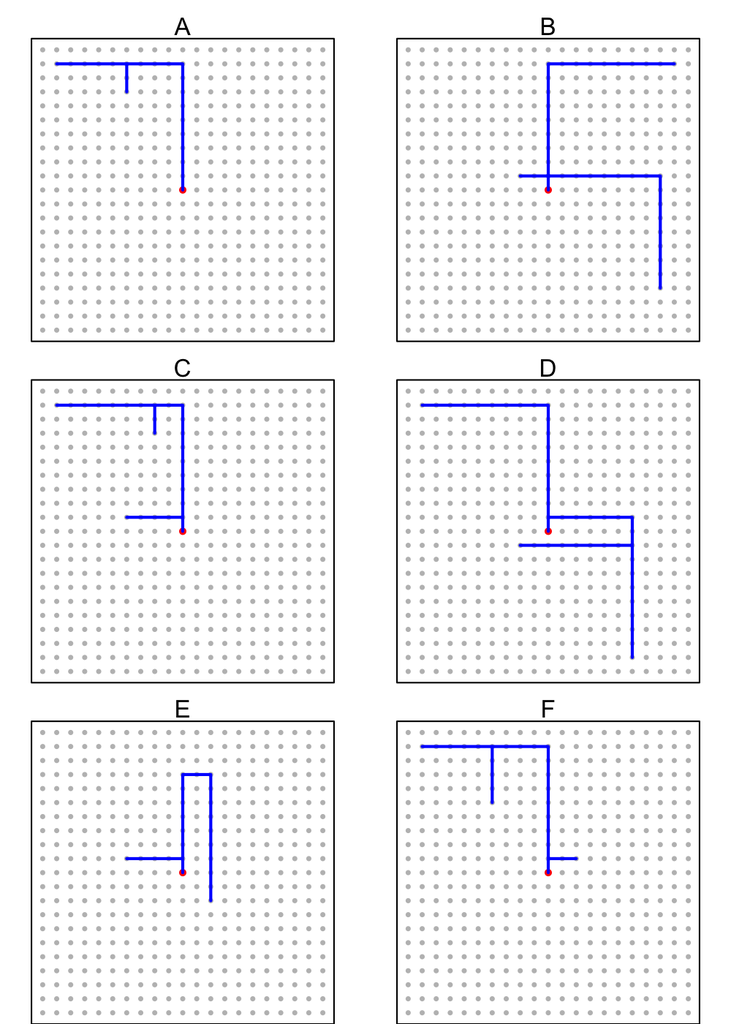

ABCDEF

The correct answer is E.

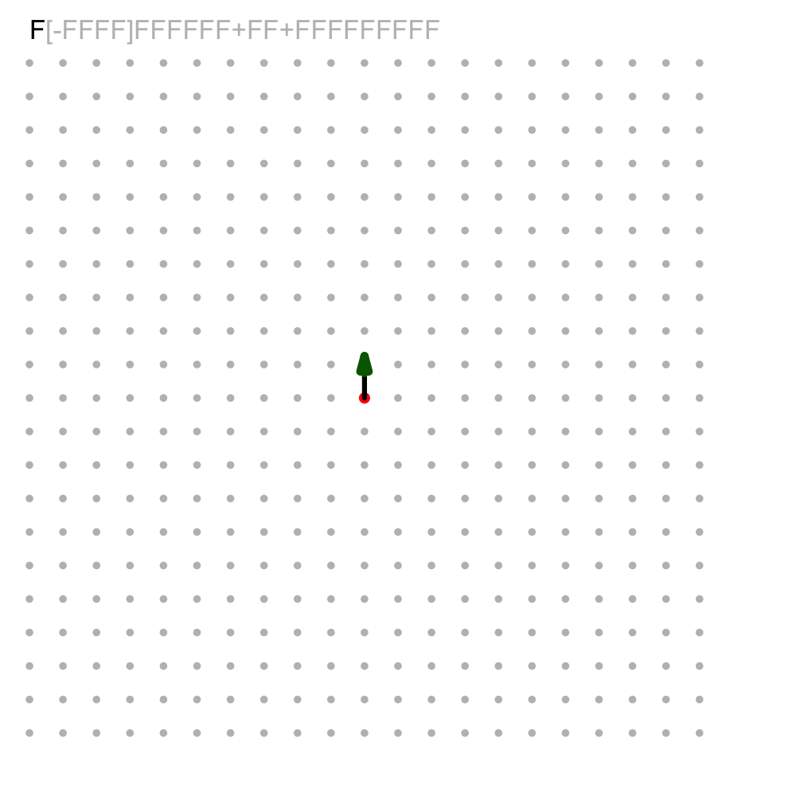

A turtle starts at the central red dot facing North. It uses the following commands:

- Character `F` means drag pen **Forward**
- Character `+` means turn 90° right (clockwise)
- Character `-` means turn 90° left (counterclockwise)
- Character `X` means hop forward without drawing
- Character `[` means save current position at top of pile
- Character `]` means teleport to saved position (use position at top of pile and remove that position from pile)

Use the following command string:

`F[-FFFF]FFFFFF[+FF]FF+FFFFFFFFF`

Which drawing is correct?

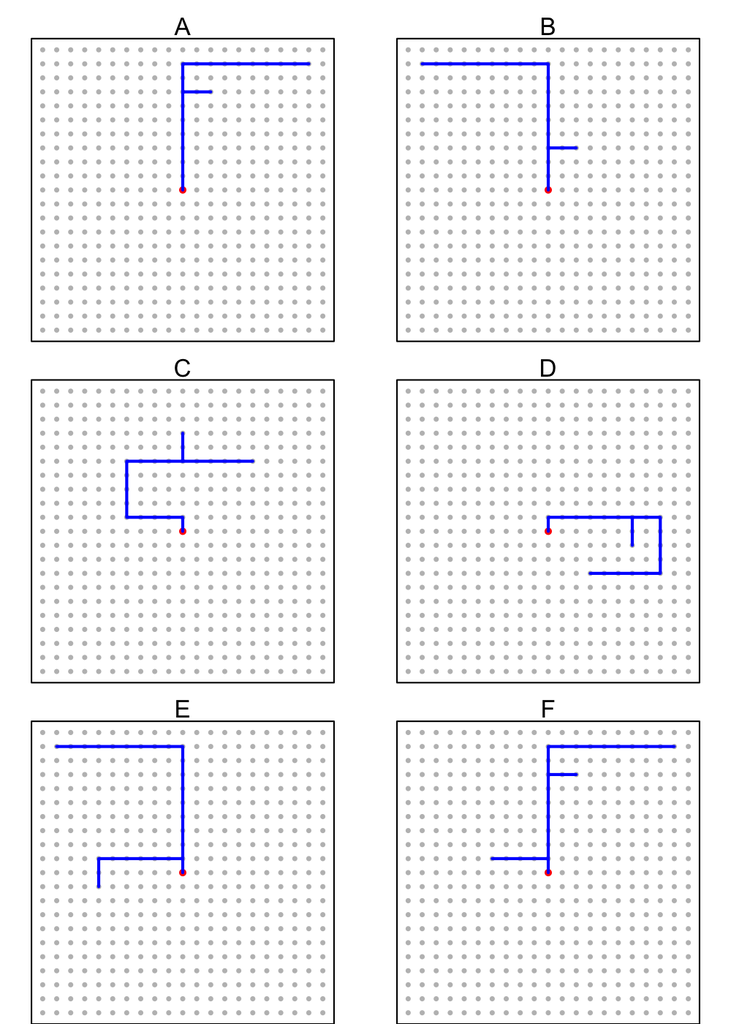

ABCDEF

The correct answer is F.

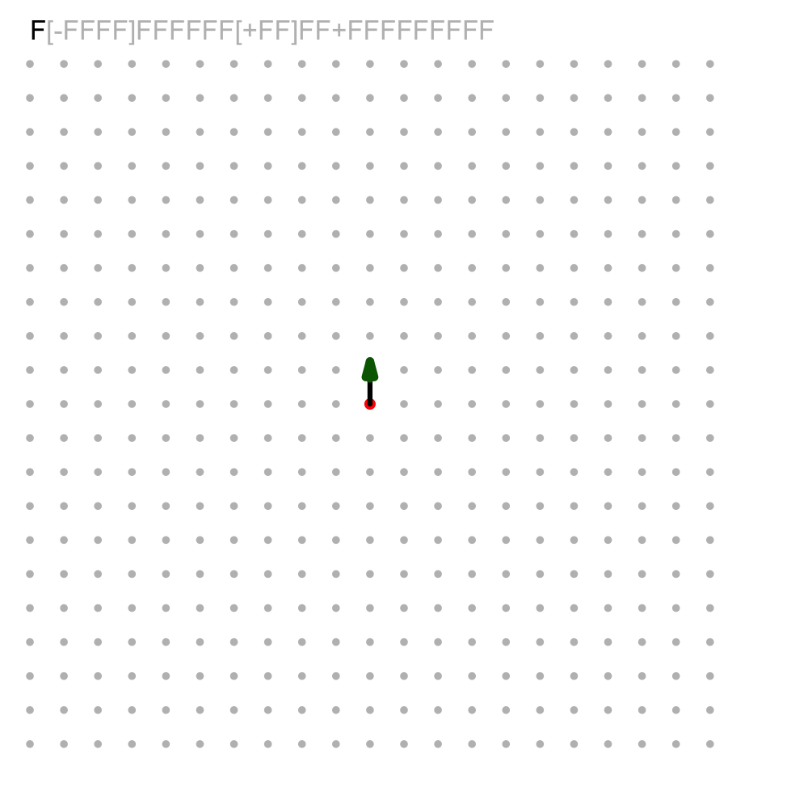

Consider the $L$-system (and turn angle) defined below:

- Start: `AA`
- Rules:  
  `A > A++B-C-B++A`  
  `B > B--A+C+A--B`  
  `C > CC`
- Number of recursions (number of iterations):
  - 6
- Turn angle
  - 45°

Please use [this online tool](https://artockthedino.github.io/lsys.html) to generate the pattern using turtle graphics. Choose the matching pattern. (The initial angle should be $270$ degrees to match the orientation.)

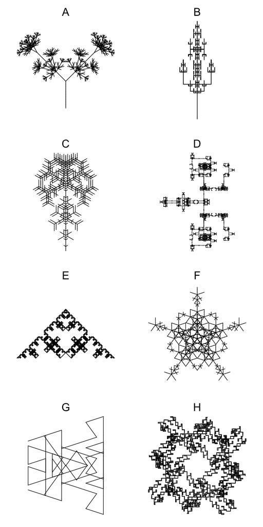

ABCDEFGH

The correct pattern is pattern E.

1. Use the first link: https://artockthedino.github.io/lsys.html
2. Copy/paste the `Axiom`, `Rules`, `Iterations`, and `Turn angle`.
3. Click `Generate Pattern`
4. Back to the quiz, select the matching pattern.

In case you're interested in the parameters of the other patterns shown:

## Pattern A

- Start: `GA`
- Rules:  
  `A > [---BC][+++BC]`  
  `B > F[--AC][++AC]`  
  `C > FF[-BA][+BA]`  
  `F > FF`  
  `G > F`
- Number of recursions (number of iterations):
  - 5
- Angle
  - 15

## Pattern B

- Start: `A`
- Rules:  
  `A > CAA[--CAB][++CAB]`  
  `B > C[-CC-CA][+CC+CA]`  
  `C > CC`
- Number of recursions (number of iterations):
  - 5
- Angle
  - 90

## Pattern C

- Start: `A`
- Rules:  
  `A > AA[-B][+B]B`  
  `B > B[-ABC][+ABC]`  
  `C > C[-CBA][+CBA]`
- Number of recursions (number of iterations):
  - 4
- Angle
  - 60

## Pattern D

- Start: `A`
- Rules:  
  `A > +B++A-XCX-A++B+`  
  `B > -AX--BCB--XA-`  
  `C > C+AXBXA+C`  
  `X > XDX`  
  `D > DD`
- Number of recursions (number of iterations):
  - 5
- Angle
  - 90

## Pattern E

- Start: `AA`
- Rules:  
  `A > A++B-C-B++A`  
  `B > B--A+C+A--B`  
  `C > CC`
- Number of recursions (number of iterations):
  - 6
- Angle
  - 45

## Pattern F

- Start: `A`
- Rules:  
  `A > [-AAB][--AAB][+AAB][++AAB]AAB`  
  `B > [-C][+C][--C][++C]CA`  
  `C > CC`
- Number of recursions (number of iterations):
  - 3
- Angle
  - 72

## Pattern G

- Start: `A`
- Rules:  
  `A > +B-AA-B+`  
  `B > -A+BB+A-`
- Number of recursions (number of iterations):
  - 3
- Angle
  - 108

## Pattern H

- Start: `A+A+A+A`
- Rules:  
  `A > C[++CB][--CB]`  
  `B > C-BAB+C`  
  `C > CAB`
- Number of recursions (number of iterations):
  - 6
- Angle
  - 90

Consider the $L$-system (and turn angle) defined below:

- Start: `AAA`
- Rules:  
  `A > C--AA++B++AA--C`  
  `B > BA+C+AB`  
  `C > -B-CA++AC-B-`
- Number of recursions (number of iterations):
  - 4
- Turn angle
  - 30°

Please use [this online tool](https://artockthedino.github.io/lsys.html) to generate the pattern using turtle graphics. Choose the matching pattern. (The initial angle should be $270$ degrees to match the orientation.)

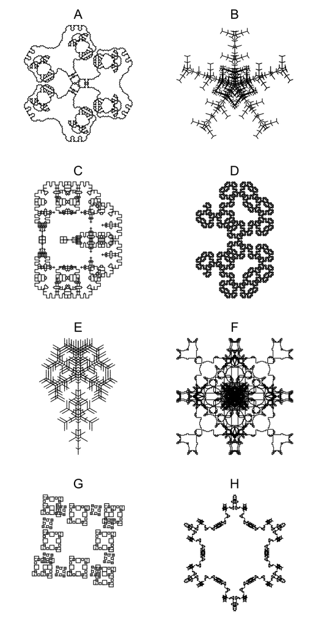

ABCDEFGH

The correct pattern is pattern A.

1. Use the first link: https://artockthedino.github.io/lsys.html
2. Copy/paste the `Axiom`, `Rules`, `Iterations`, and `Turn angle`.
3. Click `Generate Pattern`
4. Back to the quiz, select the matching pattern.

In case you're interested in the parameters of the other patterns shown:

## Pattern A

- Start: `AAA`
- Rules:  
  `A > C--AA++B++AA--C`  
  `B > BA+C+AB`  
  `C > -B-CA++AC-B-`
- Number of recursions (number of iterations):
  - 4
- Angle
  - 30

## Pattern B

- Start: `A+A+A`
- Rules:  
  `A > [+BCC][-BCC]`  
  `B > B[-CA][+CA]`  
  `C > CCA`
- Number of recursions (number of iterations):
  - 5
- Angle
  - 72

## Pattern C

- Start: `A`
- Rules:  
  `A > +BAA-ABA-AAB+`  
  `B > -A+B[-C]B+A-`  
  `C > CCCC[A][+A][-A][--A]`
- Number of recursions (number of iterations):
  - 4
- Angle
  - 90

## Pattern D

- Start: `A`
- Rules:  
  `A > +BA-ABA-AB+`  
  `B > -AB+BAB+BA-`
- Number of recursions (number of iterations):
  - 5
- Angle
  - 90

## Pattern E

- Start: `A`
- Rules:  
  `A > AA[-B][+B]B`  
  `B > B[-ABC][+ABC]`  
  `C > C[-CBA][+CBA]`
- Number of recursions (number of iterations):
  - 4
- Angle
  - 60

## Pattern F

- Start: `A++A++A++A`
- Rules:  
  `A > +B-CAC-B+`  
  `B > -A++BB++A-`  
  `C > CC`
- Number of recursions (number of iterations):
  - 6
- Angle
  - 45

## Pattern G

- Start: `A`
- Rules:  
  `A > XX[B+BB+BB+BB+B]`  
  `X > XX`  
  `B > BA`
- Number of recursions (number of iterations):
  - 6
- Angle
  - 90

## Pattern H

- Start: `AAAAAA`
- Rules:  
  `A > +B-AXB---ACA---BXA-B+`  
  `B > -A++BXA+++C+++AXB++A-`  
  `C > CC+CC`  
  `X > ++BAX+C+XAB++`
- Number of recursions (number of iterations):
  - 3
- Angle
  - 60

Consider the $L$-system (and turn angle) defined below:

- Start: `A`
- Rules:  
  `A > +B-AAA-B+`  
  `B > -A+BBB+A-`
- Number of recursions (number of iterations):
  - 5
- Turn angle
  - 120°

Please use [this online tool](https://artockthedino.github.io/lsys.html) to generate the pattern using turtle graphics. Choose the matching pattern. (The initial angle should be $270$ degrees to match the orientation.)

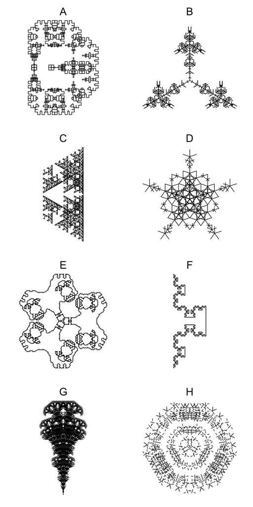

ABCDEFGH

The correct pattern is pattern C.

1. Use the first link: https://artockthedino.github.io/lsys.html
2. Copy/paste the `Axiom`, `Rules`, `Iterations`, and `Turn angle`.
3. Click `Generate Pattern`
4. Back to the quiz, select the matching pattern.

In case you're interested in the parameters of the other patterns shown:

## Pattern A

- Start: `A`
- Rules:  
  `A > +BAA-ABA-AAB+`  
  `B > -A+B[-C]B+A-`  
  `C > CCCC[A][+A][-A][--A]`
- Number of recursions (number of iterations):
  - 4
- Angle
  - 90

## Pattern B

- Start: `[A]+[A]+[A]`
- Rules:  
  `A > AA[-B][+B]B`  
  `B > [-ABC][+ABC]`  
  `C > A[-CB][+CB]`
- Number of recursions (number of iterations):
  - 4
- Angle
  - 120

## Pattern C

- Start: `A`
- Rules:  
  `A > +B-AAA-B+`  
  `B > -A+BBB+A-`
- Number of recursions (number of iterations):
  - 5
- Angle
  - 120

## Pattern D

- Start: `A`
- Rules:  
  `A > [-AAB][--AAB][+AAB][++AAB]AAB`  
  `B > [-C][+C][--C][++C]CA`  
  `C > CC`
- Number of recursions (number of iterations):
  - 3
- Angle
  - 72

## Pattern E

- Start: `AAA`
- Rules:  
  `A > C--AA++B++AA--C`  
  `B > BA+C+AB`  
  `C > -B-CA++AC-B-`
- Number of recursions (number of iterations):
  - 4
- Angle
  - 30

## Pattern F

- Start: `-A`
- Rules:  
  `A > A++B-C-B++A`  
  `B > B--A+C+A--B`  
  `C > CCC`
- Number of recursions (number of iterations):
  - 5
- Angle
  - 45

## Pattern G

- Start: `A`
- Rules:  
  `A > A[+A][-A]A[+B][-B]`  
  `B > A[--B][++B]B`
- Number of recursions (number of iterations):
  - 5
- Angle
  - 20

## Pattern H

- Start: `[A]+++[A]+++[A]`
- Rules:  
  `A > A[---XB][-XB][+XB][+++XB]`  
  `B > XB[++XA][--XA]A`  
  `X > XX`
- Number of recursions (number of iterations):
  - 4
- Angle
  - 40

Consider the $L$-system (and turn angle) defined below:

- Start: `B`
- Rules:  
  `A > [++XXBC][--XXBC][++++XXBC]`  
  `B > [-BA][+BA]`  
  `C > AB`  
  `X > XX`
- Number of recursions (number of iterations):
  - 6
- Turn angle
  - 45°

Please use [this online tool](https://artockthedino.github.io/lsys.html) to generate the pattern using turtle graphics. Choose the matching pattern. (The initial angle should be $270$ degrees to match the orientation.)

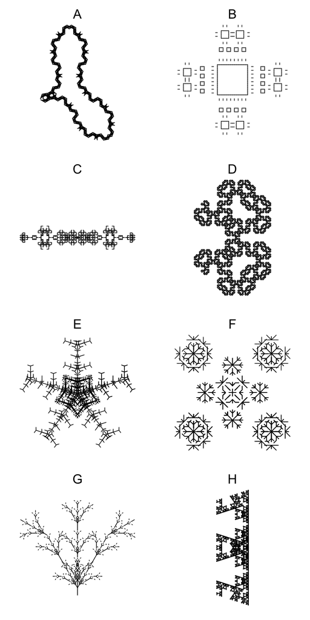

ABCDEFGH

The correct pattern is pattern F.

1. Use the first link: https://artockthedino.github.io/lsys.html
2. Copy/paste the `Axiom`, `Rules`, `Iterations`, and `Turn angle`.
3. Click `Generate Pattern`
4. Back to the quiz, select the matching pattern.

In case you're interested in the parameters of the other patterns shown:

## Pattern A

- Start: `A`
- Rules:  
  `A > +++BA----ABA----AB+++`  
  `B > ---AB++++BAB++++BA---`
- Number of recursions (number of iterations):
  - 4
- Angle
  - 50

## Pattern B

- Start: `A`
- Rules:  
  `A > XXX-B+BB+BB+BB+B`  
  `X > XX`  
  `B > B[-XXA]B`
- Number of recursions (number of iterations):
  - 4
- Angle
  - 90

## Pattern C

- Start: `AA`
- Rules:  
  `A > +B-A+X+A-B+`  
  `B > -BA+BAXAB+AB-`  
  `X > XX`
- Number of recursions (number of iterations):
  - 4
- Angle
  - 90

## Pattern D

- Start: `A`
- Rules:  
  `A > +BA-ABA-AB+`  
  `B > -AB+BAB+BA-`
- Number of recursions (number of iterations):
  - 5
- Angle
  - 90

## Pattern E

- Start: `A+A+A`
- Rules:  
  `A > [+BCC][-BCC]`  
  `B > B[-CA][+CA]`  
  `C > CCA`
- Number of recursions (number of iterations):
  - 5
- Angle
  - 72

## Pattern F

- Start: `B`
- Rules:  
  `A > [++XXBC][--XXBC][++++XXBC]`  
  `B > [-BA][+BA]`  
  `C > AB`  
  `X > XX`
- Number of recursions (number of iterations):
  - 6
- Angle
  - 45

## Pattern G

- Start: `X`
- Rules:  
  `F > FF`  
  `X > FF[+XFFX+XF][-XFFX-XF]FXXFX`
- Number of recursions (number of iterations):
  - 3
- Angle
  - 30

## Pattern H

- Start: `AA`
- Rules:  
  `A > +B-AAA-B+`  
  `B > -A+BBB+A-`
- Number of recursions (number of iterations):
  - 5
- Angle
  - 108

Consider the $L$-system (and turn angle) defined below:

- Start: `-A`
- Rules:  
  `A > A++B-C-B++A`  
  `B > B--A+C+A--B`  
  `C > CCC`
- Number of recursions (number of iterations):
  - 5
- Turn angle
  - 45°

Please use [this online tool](https://artockthedino.github.io/lsys.html) to generate the pattern using turtle graphics. Choose the matching pattern. (The initial angle should be $270$ degrees to match the orientation.)

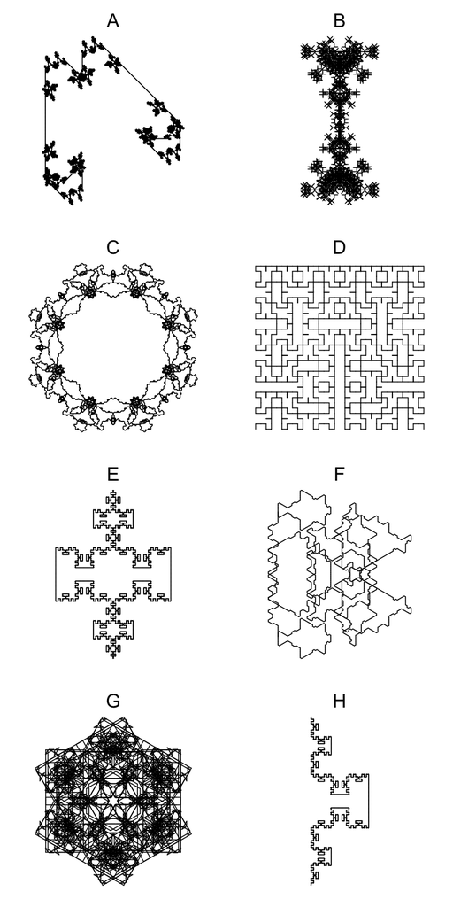

ABCDEFGH

The correct pattern is pattern H.

1. Use the first link: https://artockthedino.github.io/lsys.html
2. Copy/paste the `Axiom`, `Rules`, `Iterations`, and `Turn angle`.
3. Click `Generate Pattern`
4. Back to the quiz, select the matching pattern.

In case you're interested in the parameters of the other patterns shown:

## Pattern A

- Start: `A`
- Rules:  
  `A > +B-ACA-ACA-B+`  
  `B > -A+BCB+BCB+A-`  
  `C > CCC`
- Number of recursions (number of iterations):
  - 5
- Angle
  - 135

## Pattern B

- Start: `A++++XA`
- Rules:  
  `A > AA[-B][+B]B`  
  `B > [---ABC][+++ABC]`  
  `C > A[-CB][+CB]`  
  `X > XX`
- Number of recursions (number of iterations):
  - 5
- Angle
  - 45

## Pattern C

- Start: `AAAAAAAA`
- Rules:  
  `A > C--A++B++A--C`  
  `B > BA+C+AB`  
  `C > -B-CA+AC-B-`
- Number of recursions (number of iterations):
  - 4
- Angle
  - 45

## Pattern D

- Start: `-A`
- Rules:  
  `A > +B-AA-B+`  
  `B > -A+BB+A-`
- Number of recursions (number of iterations):
  - 5
- Angle
  - 90

## Pattern E

- Start: `-A++A`
- Rules:  
  `A > A++B-C-B++A`  
  `B > B--A+C+A--B`  
  `C > CCC`
- Number of recursions (number of iterations):
  - 5
- Angle
  - 45

## Pattern F

- Start: `A`
- Rules:  
  `A > ADB+D+BDA`  
  `B > C-DAD-C`  
  `C > B+A-D-A+B`  
  `D > DD`
- Number of recursions (number of iterations):
  - 5
- Angle
  - 60

## Pattern G

- Start: `AAAAAA`
- Rules:  
  `A > +BACA-A-CC-A-ACAB+`  
  `B > -AC+++BAACCCAAB+++CA-`  
  `C > CC`
- Number of recursions (number of iterations):
  - 3
- Angle
  - 150

## Pattern H

- Start: `-A`
- Rules:  
  `A > A++B-C-B++A`  
  `B > B--A+C+A--B`  
  `C > CCC`
- Number of recursions (number of iterations):
  - 5
- Angle
  - 45

Consider the $L$-system (and turn angle) defined below:

- Start: `A`
- Rules:  
  `A > C--A++B++A--C`  
  `B > BA+C+AB`  
  `C > -B-CA+AC-B-`
- Number of recursions (number of iterations):
  - 5
- Turn angle
  - 60°

Please use [this online tool](https://artockthedino.github.io/lsys.html) to generate the pattern using turtle graphics. Choose the matching pattern. (The initial angle should be $270$ degrees to match the orientation.)

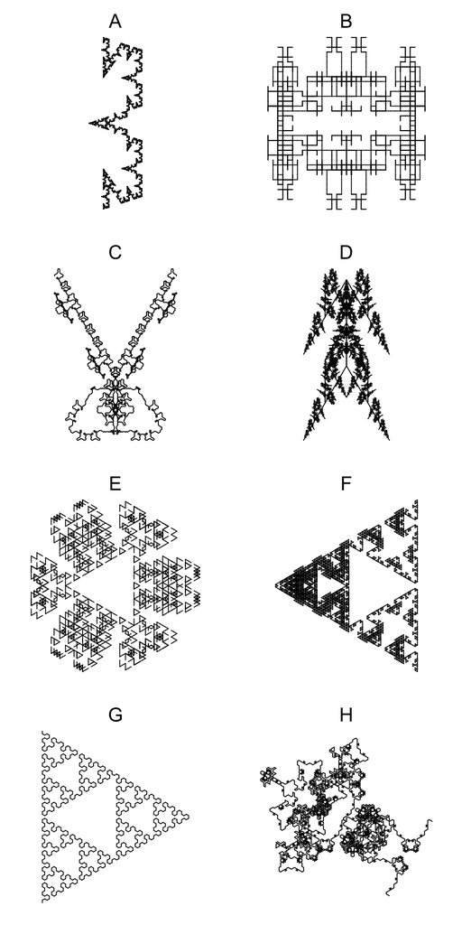

ABCDEFGH

The correct pattern is pattern H.

1. Use the first link: https://artockthedino.github.io/lsys.html
2. Copy/paste the `Axiom`, `Rules`, `Iterations`, and `Turn angle`.
3. Click `Generate Pattern`
4. Back to the quiz, select the matching pattern.

In case you're interested in the parameters of the other patterns shown:

## Pattern A

- Start: `A`
- Rules:  
  `A > B-ABA-B`  
  `B > A+B+A`
- Number of recursions (number of iterations):
  - 6
- Angle
  - 72

## Pattern B

- Start: `B--B`
- Rules:  
  `A > +B++A-DCD-A++B+`  
  `B > -AD--BCB--DA-`  
  `C > C+ADBDA+C`  
  `D > DD`
- Number of recursions (number of iterations):
  - 4
- Angle
  - 90

## Pattern C

- Start: `A`
- Rules:  
  `A > A--ACB+C+BCA--A`  
  `B > BA+++C+++AB`  
  `C > -B--A+C+A--B-`
- Number of recursions (number of iterations):
  - 4
- Angle
  - 30

## Pattern D

- Start: `[+A][-B]`
- Rules:  
  `A > [-CA-CB]CA`  
  `B > [+CB+CA]CB`  
  `C > CC`
- Number of recursions (number of iterations):
  - 6
- Angle
  - 150

## Pattern E

- Start: `A-A-A`
- Rules:  
  `A > +B-A+X+A-B+`  
  `B > -BA+BAXAB+AB-`  
  `X > XX`
- Number of recursions (number of iterations):
  - 4
- Angle
  - 120

## Pattern F

- Start: `A`
- Rules:  
  `A > B-ABA-B`  
  `B > A+B+A`
- Number of recursions (number of iterations):
  - 6
- Angle
  - 120

## Pattern G

- Start: `A`
- Rules:  
  `A > B-A-B`  
  `B > A+B+A`
- Number of recursions (number of iterations):
  - 6
- Angle
  - 60

## Pattern H

- Start: `A`
- Rules:  
  `A > C--A++B++A--C`  
  `B > BA+C+AB`  
  `C > -B-CA+AC-B-`
- Number of recursions (number of iterations):
  - 5
- Angle
  - 60

Consider the $L$-system (and turn angle) defined below:

- Start: `A`
- Rules:  
  `A > AB`  
  `B > A[++C][--C]`  
  `C > C[+C][-C]A`
- Number of recursions (number of iterations):
  - 7
- Turn angle
  - 45°

Please use [this online tool](https://artockthedino.github.io/lsys.html) to generate the pattern using turtle graphics. Choose the matching pattern. (The initial angle should be $270$ degrees to match the orientation.)

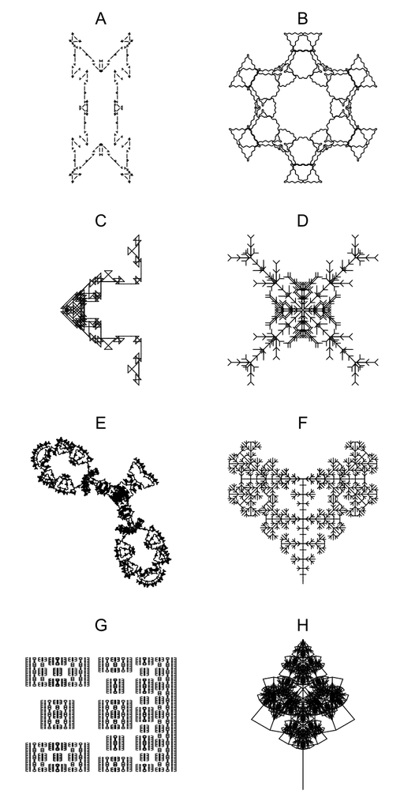

ABCDEFGH

The correct pattern is pattern F.

1. Use the first link: https://artockthedino.github.io/lsys.html
2. Copy/paste the `Axiom`, `Rules`, `Iterations`, and `Turn angle`.
3. Click `Generate Pattern`
4. Back to the quiz, select the matching pattern.

In case you're interested in the parameters of the other patterns shown:

## Pattern A

- Start: `A++++A`
- Rules:  
  `A > +B-AXBBXA-B+`  
  `B > -A+BXAAXB+A-`  
  `X > XX`
- Number of recursions (number of iterations):
  - 3
- Angle
  - 135

## Pattern B

- Start: `AAAAAA`
- Rules:  
  `A > C--ABA+B+ABA--C`  
  `B > BA+C+AB`  
  `C > -B-CA++AC-B-`
- Number of recursions (number of iterations):
  - 3
- Angle
  - 30

## Pattern C

- Start: `A`
- Rules:  
  `A > B-ABA-B`  
  `B > A+B+A`
- Number of recursions (number of iterations):
  - 4
- Angle
  - 135

## Pattern D

- Start: `A++++A`
- Rules:  
  `A > [+BCC][-BCC]`  
  `B > B[-CA][+CA]`  
  `C > CCA`
- Number of recursions (number of iterations):
  - 5
- Angle
  - 45

## Pattern E

- Start: `BB`
- Rules:  
  `A > +BA+A-ABA-A+AB+`  
  `B > +BBA-B--B-ABB+`
- Number of recursions (number of iterations):
  - 4
- Angle
  - 69

## Pattern F

- Start: `A`
- Rules:  
  `A > AB`  
  `B > A[++C][--C]`  
  `C > C[+C][-C]A`
- Number of recursions (number of iterations):
  - 7
- Angle
  - 45

## Pattern G

- Start: `A`
- Rules:  
  `A > +BX-AA-XB+`  
  `B > -AX+B+XA-`  
  `X > XX`
- Number of recursions (number of iterations):
  - 7
- Angle
  - 90

## Pattern H

- Start: `A`
- Rules:  
  `A > CAA[--CAB][++CAB]`  
  `B > C[-CC-CA][+CC+CA]`  
  `C > CC`
- Number of recursions (number of iterations):
  - 5
- Angle
  - 100

Consider the $L$-system (and turn angle) defined below:

- Start: `AAAA`
- Rules:  
  `A > +B++ACA++B+`  
  `B > -A--BCB--A-`  
  `C > CC`
- Number of recursions (number of iterations):
  - 5
- Turn angle
  - 45°

Please use [this online tool](https://artockthedino.github.io/lsys.html) to generate the pattern using turtle graphics. Choose the matching pattern. (The initial angle should be $270$ degrees to match the orientation.)

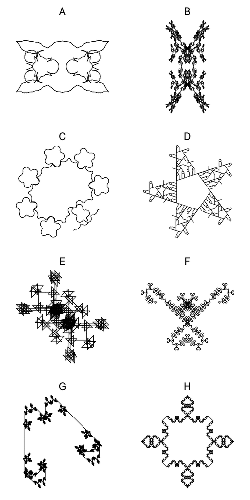

ABCDEFGH

The correct pattern is pattern H.

1. Use the first link: https://artockthedino.github.io/lsys.html
2. Copy/paste the `Axiom`, `Rules`, `Iterations`, and `Turn angle`.
3. Click `Generate Pattern`
4. Back to the quiz, select the matching pattern.

In case you're interested in the parameters of the other patterns shown:

## Pattern A

- Start: `AA`
- Rules:  
  `A > A--ACB+C+BCA--A`  
  `B > BA+++C+++AB`  
  `C > -B--A+C+A--B-`
- Number of recursions (number of iterations):
  - 4
- Angle
  - 174

## Pattern B

- Start: `A++++++A`
- Rules:  
  `A > +B-AXBXA-B+`  
  `B > -A+BXAXB+A-`  
  `X > XX`
- Number of recursions (number of iterations):
  - 5
- Angle
  - 150

## Pattern C

- Start: `A`
- Rules:  
  `A > +BAA-A-CC-A-AAB+`  
  `B > -C+++BAACAAB+++C-`  
  `C > CC`
- Number of recursions (number of iterations):
  - 4
- Angle
  - 10

## Pattern D

- Start: `A`
- Rules:  
  `A > B+B+B+B+B`  
  `B > [-CCA]BB`  
  `C > CC`
- Number of recursions (number of iterations):
  - 5
- Angle
  - 72

## Pattern E

- Start: `A++A++A++A`
- Rules:  
  `A > B-CAC-B`  
  `B > AB-BA`  
  `C > CC`
- Number of recursions (number of iterations):
  - 5
- Angle
  - 135

## Pattern F

- Start: `AA`
- Rules:  
  `A > B-AA-B`  
  `B > A+B+A`
- Number of recursions (number of iterations):
  - 6
- Angle
  - 45

## Pattern G

- Start: `A`
- Rules:  
  `A > +B-ACA-ACA-B+`  
  `B > -A+BCB+BCB+A-`  
  `C > CCC`
- Number of recursions (number of iterations):
  - 5
- Angle
  - 135

## Pattern H

- Start: `AAAA`
- Rules:  
  `A > +B++ACA++B+`  
  `B > -A--BCB--A-`  
  `C > CC`
- Number of recursions (number of iterations):
  - 5
- Angle
  - 45

Consider the $L$-system (and turn angle) defined below:

- Start: `[A]--[A]--[A]--[A]`
- Rules:  
  `A > C[+CB][CCA][-CB]`  
  `B > CCC[+++A][---A]`  
  `C > CA`
- Number of recursions (number of iterations):
  - 4
- Turn angle
  - 45°

Please use [this online tool](https://artockthedino.github.io/lsys.html) to generate the pattern using turtle graphics. Choose the matching pattern. (The initial angle should be $270$ degrees to match the orientation.)

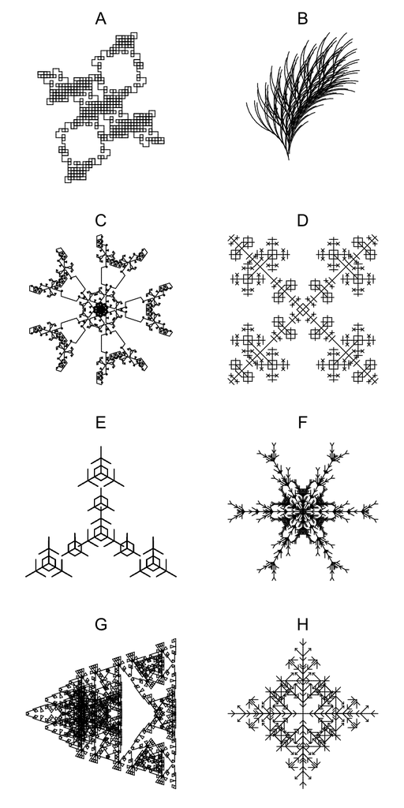

ABCDEFGH

The correct pattern is pattern H.

1. Use the first link: https://artockthedino.github.io/lsys.html
2. Copy/paste the `Axiom`, `Rules`, `Iterations`, and `Turn angle`.
3. Click `Generate Pattern`
4. Back to the quiz, select the matching pattern.

In case you're interested in the parameters of the other patterns shown:

## Pattern A

- Start: `AA`
- Rules:  
  `A > B-AA-B`  
  `B > AB+B+A`
- Number of recursions (number of iterations):
  - 5
- Angle
  - 90

## Pattern B

- Start: `A`
- Rules:  
  `A > X[-B+BB+BB+BB+BB+BB+B]`  
  `X > XX`  
  `B > X[+A-AA-AA-AA-AA-AA-A]`
- Number of recursions (number of iterations):
  - 3
- Angle
  - 10

## Pattern C

- Start: `AAAAA`
- Rules:  
  `A > B--A--B`  
  `B > A+BCB+A`  
  `C > CC`
- Number of recursions (number of iterations):
  - 5
- Angle
  - 72

## Pattern D

- Start: `A`
- Rules:  
  `A > [---B][-B][+B][+++B]`  
  `B > BD[++DA][--DA]B`  
  `D > DD`
- Number of recursions (number of iterations):
  - 5
- Angle
  - 45

## Pattern E

- Start: `B`
- Rules:  
  `A > [+DBC][-DBC][+++DBC]`  
  `B > [-BA][+BA]`  
  `C > AB`  
  `D > XX`  
  `X > XX`
- Number of recursions (number of iterations):
  - 6
- Angle
  - 120

## Pattern F

- Start: `A++++A++++A`
- Rules:  
  `A > [+BCC][-BCC]`  
  `B > B[-CA][+CA]`  
  `C > CCA`
- Number of recursions (number of iterations):
  - 5
- Angle
  - 30

## Pattern G

- Start: `A`
- Rules:  
  `A > B-ABA-B`  
  `B > A+B+A`
- Number of recursions (number of iterations):
  - 6
- Angle
  - 108

## Pattern H

- Start: `[A]--[A]--[A]--[A]`
- Rules:  
  `A > C[+CB][CCA][-CB]`  
  `B > CCC[+++A][---A]`  
  `C > CA`
- Number of recursions (number of iterations):
  - 4
- Angle
  - 45

Consider the $L$-system (and turn angle) defined below:

- Start: `B---A`
- Rules:  
  `A > A[-AB]A`  
  `B > B[+BA]B`
- Number of recursions (number of iterations):
  - 5
- Turn angle
  - 60°

Please use [this online tool](https://artockthedino.github.io/lsys.html) to generate the pattern using turtle graphics. Choose the matching pattern. (The initial angle should be $270$ degrees to match the orientation.)

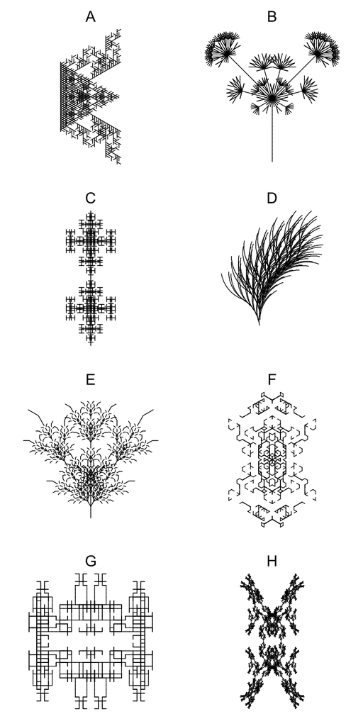

ABCDEFGH

The correct pattern is pattern A.

1. Use the first link: https://artockthedino.github.io/lsys.html
2. Copy/paste the `Axiom`, `Rules`, `Iterations`, and `Turn angle`.
3. Click `Generate Pattern`
4. Back to the quiz, select the matching pattern.

In case you're interested in the parameters of the other patterns shown:

## Pattern A

- Start: `B---A`
- Rules:  
  `A > A[-AB]A`  
  `B > B[+BA]B`
- Number of recursions (number of iterations):
  - 5
- Angle
  - 60

## Pattern B

- Start: `GA`
- Rules:  
  `A > [---BC][+++BC]`  
  `B > [--AC][++AC]`  
  `C > FF[-BA][+BA]`  
  `F > FF`  
  `G > F`
- Number of recursions (number of iterations):
  - 5
- Angle
  - 15

## Pattern C

- Start: `AA`
- Rules:  
  `A > ABA`  
  `B > C[-BAB][+BAB]`  
  `C > CC`
- Number of recursions (number of iterations):
  - 5
- Angle
  - 90

## Pattern D

- Start: `A`
- Rules:  
  `A > X[-B+BB+BB+BB+BB+BB+B]`  
  `X > XX`  
  `B > X[+A-AA-AA-AA-AA-AA-A]`
- Number of recursions (number of iterations):
  - 3
- Angle
  - 10

## Pattern E

- Start: `X`
- Rules:  
  `F > FF`  
  `X > F[+XXF+F][-XXF-F]FXX`
- Number of recursions (number of iterations):
  - 4
- Angle
  - 30

## Pattern F

- Start: `AA`
- Rules:  
  `A > +B-AXB---ACA---BXA-B+`  
  `B > -A++BXA+C+AXB++A-`  
  `C > C+C`  
  `X > XXX`
- Number of recursions (number of iterations):
  - 3
- Angle
  - 60

## Pattern G

- Start: `B--B`
- Rules:  
  `A > +B++A-DCD-A++B+`  
  `B > -AD--BCB--DA-`  
  `C > C+ADBDA+C`  
  `D > DD`
- Number of recursions (number of iterations):
  - 4
- Angle
  - 90

## Pattern H

- Start: `A++++++A`
- Rules:  
  `A > +B-AXBXA-B+`  
  `B > -A+BXAXB+A-`  
  `X > XX`
- Number of recursions (number of iterations):
  - 5
- Angle
  - 150